```python
%run import.py
```

# Regression

For regression the general prediction fromula look like:

$$ \hat{y}=w[0]*x[0]+w[1]*x[1]+...+w[p]*x[p]+b $$

the x's are the fetures of a single data point, w and b are paramters of the model that are learned. $\hat{y}$ is the prediction of the model. For a dataset with a single feature this becomes

$$ \hat{y}=w[0]*x[0]+b $$

To start our investigation we will look at learning paramters from the `wave` dataset

```
w[0]: 0.393906  b: -0.031804
```

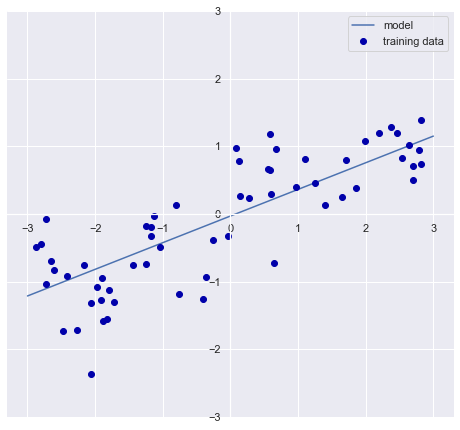

```python
from mglearn import cm2
X, y = mglearn.datasets.make_wave(n_samples=60)
X_train, X_test, y_train, y_test = train_test_split(X, y, random_state=42)

line = np.linspace(-3, 3, 100).reshape(-1, 1)

lr = LinearRegression().fit(X_train, y_train)
print("w[0]: %f  b: %f" % (lr.coef_[0], lr.intercept_))

plt.figure(figsize=(8, 8))
plt.plot(line, lr.predict(line))
plt.plot(X, y, 'o', c=cm2(0))
ax = plt.gca()
ax.spines['left'].set_position('center')
ax.spines['right'].set_color('none')
ax.spines['bottom'].set_position('center')
ax.spines['top'].set_color('none')
ax.set_ylim(-3, 3)
    #ax.set_xlabel("Feature")
    #ax.set_ylabel("Target")
ax.legend(["model", "training data"], loc="best")
ax.grid(True)
ax.set_aspect('equal')
```

Lets compare how our line generalizes between the training and test set:

```python
print("Training set score: {:.2f}".format(lr.score(X_train, y_train)))
print("Test set score: {:.2f}".format(lr.score(X_test, y_test)))
```

```
Training set score: 0.67
Test set score: 0.66
```

The $R^2$ score of .66 is not very good, but we can see that the scores are pretty close to eachother. This means that we are likely underfitting the data. For one dimensional data there is little danger of overfitting. With higher dimensional data the model complexity increases and there is a higher chance of overfitting. Lets look at a larger data se the `Boston Housing` data set. there are 506 samples with 104 derived features.

```python
 X, y = mglearn.datasets.load_extended_boston()
X_train, X_test, y_train, y_test = train_test_split(X, y, random_state=0)
lr = LinearRegression().fit(X_train, y_train)

print(X.shape)
print(y.shape)
```

```
(506, 104)
(506,)
```

[output not shown]

Lets compare the score on the trining and test sets:

```python
print("Training set score: {:.2f}".format(lr.score(X_train, y_train)))
print("Test set score: {:.2f}".format(lr.score(X_test, y_test)))
```

```
Training set score: 0.95
Test set score: 0.61
```

The discrepency between the training and test set is a clear sign of overfitting. Therfore we need a way to control the complexity. One way to do this is through feature selection and comparing diffferent features in each model. An alternative is a different type of regression that adds aditional constraints

## Ridge regression

The additional constraint of ridge regression is that the magnitudes of the weights should be as small as possible while still predicting the data well. This constraing is and example of *regularization*. Regularization means explicitly restricting a model to avoid overfittiing. Ridge regression uses L2 regularization. Lets see how ridge regression preforms on the boston housing data set:

```python
from sklearn.linear_model import Ridge
ridge = Ridge().fit(X_train, y_train)
print("Training set score: {:.2f}".format(ridge.score(X_train, y_train)))
print("Test set score: {:.2f}".format(ridge.score(X_test, y_test)))
```

```
Training set score: 0.89
Test set score: 0.75
```

The ridge model makes a trad-off between simplicity and preformance on the training set. this trade off can be changed by using the **alpha** parameter. Increasing alpha forces coeficients to move toward zero which decreases training set preformance but might help generalization, for example:

```python
ridge10 = Ridge(alpha=10).fit(X_train, y_train)
print("Training set score: {:.2f}".format(ridge10.score(X_train, y_train)))
print("Test set score: {:.2f}".format(ridge10.score(X_test, y_test)))
```

```
Training set score: 0.79
Test set score: 0.64
```

By letting alpha be very small we end up not restricting the weights much at all and end up with a model that resembles linear regression:

```python
ridge01 = Ridge(alpha=0.1).fit(X_train, y_train)
print("Training set score: {:.2f}".format(ridge01.score(X_train, y_train)))
print("Test set score: {:.2f}".format(ridge01.score(X_test, y_test)))
```

```
Training set score: 0.93
Test set score: 0.77
```

We can look a t a qualitative way of understanding alpha by looking at what different alpha values do to the weights. We expect the weights to have smaller values for higher values of alpha

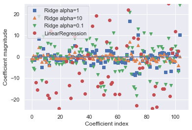

```python
plt.plot(ridge.coef_, 's', label="Ridge alpha=1")
plt.plot(ridge10.coef_, '^', label="Ridge alpha=10")
plt.plot(ridge01.coef_, 'v', label="Ridge alpha=0.1")
plt.plot(lr.coef_, 'o', label="LinearRegression")
plt.xlabel("Coefficient index")
plt.ylabel("Coefficient magnitude")
plt.hlines(0, 0, len(lr.coef_))
plt.ylim(-25, 25)
plt.legend()
```

Here the x-axis is the first 100 features of the model and the y-axis is the magnitude of the weight for that feature. Here we can see that when alpha is 10 the weights are between -3 and 3. when alpha is .1 the magnitudes of the weights are similar to plain linear regression with out regularization (alpha=0).

Another way to understand regularization is to fix alpha=1 and vary the amount of training data:

[output not shown]

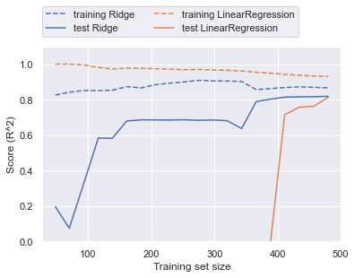

```python
mglearn.plots.plot_ridge_n_samples();
```

Here training is alaways higher than test score, but linear regression is not able to preform well until there are atleast 400 training samples. Eventually linear regression does catch up to ridge regression. Overall with enough training data regularization becomes less important. Also with more data the training preformance of linear regression decreaases. This is because it becomes harder for the model to over fit the data.

### Lasso Regression

An alternative to ridge regression is lasso regression. Again lasso also restricts the weights close to zero but does it through L1 regularization. With this L1 regularization some of the weights are **exactly zero**. This means some of the features are ignored and can be seen as a form of automatic feature selection. This can also helo to ilicit the most important features of the model. Lets apply this method to the boston housing data:

```python
from sklearn.linear_model import Lasso
lasso = Lasso().fit(X_train, y_train)
print("Training set score: {:.2f}".format(lasso.score(X_train, y_train)))
print("Test set score: {:.2f}".format(lasso.score(X_test, y_test)))
print("Number of features used:", np.sum(lasso.coef_ != 0))
```

```
Training set score: 0.29
Test set score: 0.21
Number of features used: 4
```

Lasso does quite poorly on the training and test sets, this indicates we are underfitting. The model is only using 4 of the 104 features. Lasso also has a regularization parameter *alpha*. By default this parameter is 1 . To reduce underfittin we can try and decrease alpha but we also need to increse the default setting of `max_iter`

```python
# we increase the default setting of "max_iter",
# otherwise the model would warn us that we should increase max_iter.
lasso001 = Lasso(alpha=0.01, max_iter=100000).fit(X_train, y_train)
print("Training set score: {:.2f}".format(lasso001.score(X_train, y_train)))
print("Test set score: {:.2f}".format(lasso001.score(X_test, y_test)))
print("Number of features used:", np.sum(lasso001.coef_ != 0))
```

```
Training set score: 0.90
Test set score: 0.77
Number of features used: 33
```

The lower alpha allows us to fir a more complex model. We have slightly better preformance than the ridge model and are only using 33 fetures. This may make the model potentially easier to understand. If alpha is to low we remove the effect of regularization and end up over fitting. In this case we get a similar resuklt to linear regression:

```python
lasso00001 = Lasso(alpha=0.0001, max_iter=100000).fit(X_train, y_train)
print("Training set score: {:.2f}".format(lasso00001.score(X_train, y_train)))
print("Test set score: {:.2f}".format(lasso00001.score(X_test, y_test)))
print("Number of features used:", np.sum(lasso00001.coef_ != 0))
```

```
Training set score: 0.95
Test set score: 0.64
Number of features used: 96
```

Similarly we can again look at the weights for different alph values and compare to ridge regression

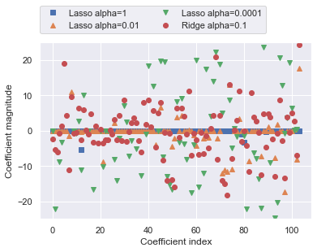

```python
plt.plot(lasso.coef_, 's', label="Lasso alpha=1")
plt.plot(lasso001.coef_, '^', label="Lasso alpha=0.01")
plt.plot(lasso00001.coef_, 'v', label="Lasso alpha=0.0001")
plt.plot(ridge01.coef_, 'o', label="Ridge alpha=0.1")
plt.legend(ncol=2, loc=(0, 1.05))
plt.ylim(-25, 25)
plt.xlabel("Coefficient index")
plt.ylabel("Coefficient magnitude")
```

In practice ridge regression is usually the first choice between the two. If you know that your data has many features but most of them will not be important lasso might be a better choice. Lasso also provides a model that is easier to understan as it will only select a subset of the input features. there is also a class call `ElasticNet` in scikit-learn, which combines the L1 and L2 penalties. This works best but there are now multiple paramters to adjust to fine tune your model.